# Predicting Drug Use Using Personailty Type and Pyschological Diagnoses- Summer 2026

A comparasion between MLP and RNN on non-sequential data

Author

Elizabeth Rose and Victoria Kipker (Advisor: Dr. Cohen)

Published

July 22, 2026

Slides: slides.html

## Introduction

In an era plagued with a severe mental health crisis accelerated by both socioeconomic strife and the cognitive overload of the information age, the temptation to cope or escape can be compelling. As individuals attempt to navigate the current global landscape, many seek assistance from unregulated sources online, such as social media, frequently leading to self-diagnosis and self-medication. This access to “over-information” and a wide variety of ever-evolving psychoactive substances available have essentially left individuals overwhelmed by choice. Consequently, a critical behavioral question remains: what innate factors influence an individual’s substance of choice?

To investigate this phenomenon, research conducted by Fehrman et al. explored individual’s risk for drug consumption using a dataset collected via an online survey (Fehrman et al. 2017). Administered over a 12-month period, the survey resulted in usable data from 1,885 participants across a range of English-speaking nations including the United Kingdom, the United States, Canada, Australia, New Zealand, and Ireland. In addition to collecting information regarding the use of 18 legal and illegal drugs, the survey collected demographic metrics, such as education level and race, as well as their personality traits.

Personality traits were assessed using the Revised NEO Five-Factor Inventory (NEO-FFI-R). This method evaluates personalities based on scores across five core dimensions: neuroticism, extraversion, openness to experience, agreeableness, and conscientiousness (Costa and McCrae 1992). This dataset established by Fehrman et al. serves as the foundation for this study. This study attempts to model the complex relationship between personality profiles and an individual’s “drug of choice”, while simultaneously predicting substance risks by implementing both traditional Deep Neural Networks (DNNs), such as the multilayer perceptron, as well as Recurrent Neural Networks (RNNs).

The concept for the function of artificial neural networks (ANNs) has always been to replicate the processing methods of the brain: a complex, multi-parallel system of individual processing units called “neurons” (Montesinos Lóperz et al. 2022) (Larochelle et al. 2009). While the inception of the artificial neuron dates back to the early 1940s, the underlying mechanism has remained fundamentally unchanged. Early iterations of ANNs were structurally simple, consisting of a single input layer, activation function, and an output layer. At the time, these models were operating with both structural and computational limitations, and as such were restricted to solving simpler, linearly separable problems (Ekundayo and Ezugwu 2025). The field then experienced a prolonged period of stagnation until it ended abruptly in 1986 with the introduction of backpropagation. This optimization method allows networks to systematically and repeatedly adjust their weights across multiple hidden layers to minimize the difference between the actual output and the desired output (Rumelhart et al. 1986). In the decades since the popularization of backpropagation, advancements in computing power and data availability have accelerated the evolution of deep learning, to the point where ANNs have permeated virtually all corners of modern data analysis.

## Methods

The multilayer perceptron (MLP) remains the standard feed-forward architecture for processing structured, tabular data. Within an MLP, information can only flow in a single direction from the input layer through to the hidden processing layer or layers. Notably, neurons within the same layer are not interconnected (El-Mandouh et al. 2026). While more advanced models have been developed, MLPs have remained the benchmark when both simplicity and computational efficiency are the primary objectives. Furthermore, many optimization techniques have been developed to fine-tune these models, significantly accelerating convergence rates during training (Przybyła-Kasperek and Marfo 2024).

The selection of an appropriate ANN is dictated by the structure of the input data. For time series data, a recurrent neural network (RNN) provides increased analytical power by incorporating short-term memory. Unlike the unidirectional flow within an MLP, an RNN allows information to propagate through feedback loops. This enables the neurons to have connections to the previous layer, connections to neurons in the subsequent layer, and connections that transmit information between other neurons within the same layer. Essentially, this built-in memory enables the model to maintain context across a sequence to link current inputs to historical information (El-Mandouh et al. 2026).

For the analysis of time series data, language data, or data with a spatial structure, such as images or videos, a convolutional neural network (CNN) is typically the most effective. These models function by applying a series of convolutional filters that perform hierarchical feature extraction. Initially, low-level details such as edges or points are analyzed, while subsequent layers analyze higher-level shapes and contours. Since CNNs utilize the spatial correlation between adjacent data points, data generally requires less preprocessing than more traditional methods (El-Mandouh et al. 2026).

For the purpose of this paper, our analysis will focus exclusively on MLP and RNN models. By comparing the feed-forward processing of the MLP against the feedback-oriented structure of the RNN, we aim to determine if personality traits are good predictors of drug use.

The MLP model developed for this analysis consists of an input layer, two hidden layers, and an output layer. The first hidden layer has 64 neurons and uses Rectified Linear Unit (ReLU) activation, where postiive values are passed through as identity and negative values are rendered as 0, while the second hidden layer has 32 neurons and also uses ReLU activation. The use of this activation function is computationally inexpensive and assists with mitigating vanishing gradient issues that arise with the use of tanh or sigmoid functions. Additionally, even thought the ReLU function will inevitably render some neurons inactive with a 0 output, we have also employed a dropout parameter which ensures network sparsity, making sure that neurons in the net do not become co-dependent. The output layer consists of 15 neurons and uses a sigmoid activation since we will be conducting a multi-label classification task.

Mathematically, these layers can be explained using the formulas below:

Hidden layer 1 Calculation with M1 neurons:
$$V1_j = g_1\left(\sum_{i=1}^{d} w^{(1)}_{ji} x_i\right) for\ j = 1, ...,M_1$$

Hidden layer 2 Calculation with M2 neurons:
$$V2_k = g_2\left(\sum_{j=1}^{M1} w^{(2)}_{kj} V1_j\right)for\ k = 1, ...,M_2$$
Output layer calculation:
$$y_l = g_3\left(\sum_{k=1}^{M2} w^{(3)}_{lk} V2_k\right)for\ l = 1, ...,M_3$$
Here, the first hidden layer processes the input features x using weights w(1). The second hidden layer then processes the output of the first hidden layer V1. Finally, the output layer is used to compute the predicted drug usage probabilities y (Montesinos Lóperz et al. 2022). The activation functions at each layer are represented by g1, g2, and g3. As previously mentioned, ReLU will be used for the hidden layers in our MLP model. This activation function performs a nonlinear transformation by acting as a switch. If the input is less than 0, then the output will be 0. However, if the input is above a certain threshold, the output is the identify of the input.

ReLU activation function:
$$f(z) = \begin{cases} 0 & \text{for } z < 0 \\ z & \text{for } z \ge 0 \end{cases}$$
The choice of output layer activation function was between sigmoid, where the probabilities of output classes are independent or the softmax equation which produces probabilities of classes that sum to 1. It is our belief that the sigmoid activation function best represents the human behavior of being equally (highly) likely to engage in multiple drugs, that a person could have multiple independent high probabilites of substance use (e.g. a person could have a 90% probability of using cocaine and an 85% probability of using meth).

Sigmoid activation function:
$$f(z) = \frac{1}{1 + e^{-z}}$$

Softmax activation function:
$$P(y = i \mid \mathbf{z}) = \frac{e^{z_i}}{\sum_{j=1}^{K} e^{z_j}}$$
The RNN model for this analysis consists of one hidden layer and a dense, or output, layer. The hidden layer is a limited short-term memory (LSTM) layer of 64 neurons that houses intermediates. The output layer then consists of 15 neurons and a sigmoid activation function, one per drug we are predicting.

The LSTM employs the use of gates to process information. There are three gates, a forget gate, which decides what previous information is no longer relevant to the processing, the input gate which filters incoming information and determines what is valuable to be saved and passed along, and the output gate which transforms information gathered and processed/filtered into a decision. These gates are mathematically described using the formulas below:

Forget gate:
$$f_t = \sigma(W_f x_t + U_f h_{t-1} + b_f)$$

Input gate:
$$i_t = \sigma(W_i x_t + U_i h_{t-1} + b_i)$$
Output gate:
$$o_t = \sigma(W_o x_t + U_o h_{t-1} + b_o)$$

# Analysis and Results

There were several preprocessing steps to make the data ready for the ANN model. We began by verifying that the data set did not need standardization. We then converted the drug columns (the targets) into a binary “user” or “non user” designation based on whether the participant has used this substance within the last year. The study also used a fake drug called “Semeron” that was used to identify participants erroneously marking drugs not actually used. We omitted any instances in the dataset where a participant recorded use of “Semer” as accuracy of the remaining disclosed drugs used could not be verified.

We then convert the features into a numeric matrix. As the goal of our model is to predict drug use on personality and demographic responses and not the use of other drugs, we must remove the other drugs from the numeric feature matrix.

Before moving onto train/test splitting the data, a class imbalance between many drug classes was observed. Applying a randomized train/test split can compound this imbalance issue and impact the model so we used a composite profile score. By using this method, individuals that use more than one drug will be evenly distributed between the train and test groups.

To prepare the data for the RNN model, we must convert the 2D matrices used for the MLP model into 3D arrays required for LSTM layers. Because the dataset used in this paper contains static personality type data rather than time series data, the LSTM layer was used to act essentially as a sequential feature extractor. Since we reshaped the 7 features into a 3D array, the variables can then be fed into the model one at a time in a fixed order, rather than all at once as in our MLP model. Here, we are forcing the LSTM to process the features sequentially, even though the data is not in a chronological order. After each individual feature is evaluated, the internal memory is updated allowing the model to evaluate the next personality trait within the context of the personality data evaluated in the previous steps.

## Data Exploration and Visualization

The dataset used in this analysis was collected via an online survey by Fehrman et al. (Fehrman et al. 2017) and initially yielded results from 2,051 individuals. To ensure data integrity, a fictitious drug “Semeron” was included as a validity check to identify inattentive respondents and individuals inflating their drug use. Information from individuals who failed this validity check or incorrectly completed the survey was removed, resulting in a usable sample size of 1885 participants. The majority of the respondents resided in the United Kingdom (55.4%) and the United States (29.5%), with the remainder from Canada, Australia, Ireland, and New Zealand. Additional demographic information collected during the survey included age, gender, education level, and ethnicity.

To assess personality traits, participants completed the Revised NEO Five-Factor Inventory (NEO-FFI-R), responding to 60 statements on a 5-point Likert scale. Impulsiveness was measured using the Barratt Impulsiveness Scale (BIS-11), which assesses three sub-factors: motor, attentional, and non-planning impulsiveness. Additionally, sensation-seeking tendencies were evaluated using the Impulsive Sensation Seeking (ImpSS) scale, consisting of 19 true/false statements.

Regarding substance use, participants reported their use of 18 legal and illegal drugs. For each substance, respondents selected from seven usage frequency categories: never used, used over a decade ago, used in the last decade, year, month, week, or day. These categorical responses were then quantified into numerical values by the original researchers, allowing the data to be processed by both statistical and machine learning models as continuous features.

Table 1 below provides an overview of the features used in this study. While the personality traits are represented as continuous values, the substance usage is represented using a scale from 0 to 6 in the literature. In Table 1, the drug use intensity responses were converted to a 1 (never used) to 7 (used in the past day) numeric index during data processing for our later modeling purposes.

```r
# Set R's seed
set.seed(10)

# Set environment variables and seeds for TensorFlow
library(reticulate)
py_run_string("
import os
os.environ['PYTHONHASHSEED'] = '10'
import random
random.seed(10)
import numpy as np
np.random.seed(10)
import tensorflow as tf
tf.random.set_seed(10)
")

library(keras)
#redundant just in case above doesnt set the correct variable
tensorflow::set_random_seed(10, disable_gpu = TRUE)
```

```r
library(knitr)
library(psych)
library(ucimlrepo)

drug_data = fetch_ucirepo(id=373)
data = drug_data$data$original
pre_drug_data = data[, 7:32]

#drug_col_indices = 8:26
#pre_drug_data[drug_col_indices] = lapply(pre_drug_data[drug_col_indices], function(x) as.numeric(x) - 1)


pre_stats = describe(pre_drug_data)

Variable_map = c(
  "nscore" = "Neuroticism score",
  "escore" = "Extraversion score",
  "oscore" = "Openness to Experience score",
  "ascore" = "Agreeableness score",
  "cscore" = "Conscientiousness score",
  "impuslive" = "Impulsiveness (BIS-11) score",
  "ss" = "Sensation Seeking (ImpSS) score",
  "alcohol*" = "Alcohol usage frequency (1-7)",
  "amphet*" = "Amphetamine usage frequency (1-7)",
  "amyl*" = "Amyl nitrite usage frequency (1-7)",
  "benzos*" = "Benzodiazepine usage frequency (1-7)",
  "caff*" = "Caffeine usage frequency (1-7)",
  "cannabis*" = "Cannabis usage frequency (1-7)",
  "choc*" = "Chocolate usage frequency (1-7)",
  "coke*" = "Cocaine usage frequency (1-7)",
  "crack*" = "Crack usage frequency (1-7)",
  "ecstasy*" = "Ecstasy usage frequency (1-7)",
  "heroin*" = "Heroin usage frequency (1-7)",
  "ketamine*" = "Ketamine usage frequency (1-7)",
  "legalh*" = "Legal highs usage frequency (1-7)",
  "lsd*" = "LSD usage frequency (1-7)",
  "meth*" = "Methadone usage frequency (1-7)",
  "mushrooms*" = "Magic mushrooms usage frequency (1-7)",
  "nicotine*" = "Nicotine usage frequency (1-7)",
  "semer*" = "Semeron (ficticious drug) usage frequency (1-7)",
  "vsa*" = "Volatile Substance Abuse usage frequency (1-7)"
)
pre_summary = data.frame(
  Substance = as.character(rownames(pre_stats)),
  Mean = round(pre_stats$mean, 2),
  SD = round(pre_stats$sd, 2),
  Min = pre_stats$min,
  Max = pre_stats$max,
  Type = c(rep("Personality", 7), rep("Drug Usage Intensity", 19)),
  stringsAsFactors = FALSE
)

pre_summary$Description = Variable_map[pre_summary$Substance]

pre_summary = pre_summary[, c("Substance", "Description", "Mean", "SD", "Min", "Max", "Type")]

kable(pre_summary, caption = "Table 1: Descriptive Statistics and Variable Descriptions")
```

Table 1: Descriptive Statistics and Variable Descriptions

| Substance | Description | Mean | SD | Min | Max | Type |
| --- | --- | --- | --- | --- | --- | --- |
| nscore | Neuroticism score | 0.00 | 1.00 | -3.46436 | 3.27393 | Personality |
| escore | Extraversion score | 0.00 | 1.00 | -3.27393 | 3.27393 | Personality |
| oscore | Openness to Experience score | 0.00 | 1.00 | -3.27393 | 2.90161 | Personality |
| ascore | Agreeableness score | 0.00 | 1.00 | -3.46436 | 3.46436 | Personality |
| cscore | Conscientiousness score | 0.00 | 1.00 | -3.46436 | 3.46436 | Personality |
| impuslive | Impulsiveness (BIS-11) score | 0.01 | 0.95 | -2.55524 | 2.90161 | Personality |
| ss | Sensation Seeking (ImpSS) score | 0.00 | 0.96 | -2.07848 | 1.92173 | Personality |
| alcohol* | Alcohol usage frequency (1-7) | 5.64 | 1.33 | 1.00000 | 7.00000 | Drug Usage Intensity |
| amphet* | Amphetamine usage frequency (1-7) | 2.34 | 1.78 | 1.00000 | 7.00000 | Drug Usage Intensity |
| amyl* | Amyl nitrite usage frequency (1-7) | 1.61 | 1.06 | 1.00000 | 7.00000 | Drug Usage Intensity |
| benzos* | Benzodiazepine usage frequency (1-7) | 2.47 | 1.87 | 1.00000 | 7.00000 | Drug Usage Intensity |
| caff* | Caffeine usage frequency (1-7) | 6.48 | 1.11 | 1.00000 | 7.00000 | Drug Usage Intensity |
| cannabis* | Cannabis usage frequency (1-7) | 3.99 | 2.29 | 1.00000 | 7.00000 | Drug Usage Intensity |
| choc* | Chocolate usage frequency (1-7) | 6.11 | 1.09 | 1.00000 | 7.00000 | Drug Usage Intensity |
| coke* | Cocaine usage frequency (1-7) | 2.16 | 1.51 | 1.00000 | 7.00000 | Drug Usage Intensity |
| crack* | Crack usage frequency (1-7) | 1.30 | 0.84 | 1.00000 | 7.00000 | Drug Usage Intensity |
| ecstasy* | Ecstasy usage frequency (1-7) | 2.31 | 1.65 | 1.00000 | 7.00000 | Drug Usage Intensity |
| heroin* | Heroin usage frequency (1-7) | 1.37 | 1.03 | 1.00000 | 7.00000 | Drug Usage Intensity |
| ketamine* | Ketamine usage frequency (1-7) | 1.57 | 1.22 | 1.00000 | 7.00000 | Drug Usage Intensity |
| legalh* | Legal highs usage frequency (1-7) | 2.36 | 1.79 | 1.00000 | 7.00000 | Drug Usage Intensity |
| lsd* | LSD usage frequency (1-7) | 2.06 | 1.49 | 1.00000 | 7.00000 | Drug Usage Intensity |
| meth* | Methadone usage frequency (1-7) | 1.83 | 1.65 | 1.00000 | 7.00000 | Drug Usage Intensity |
| mushrooms* | Magic mushrooms usage frequency (1-7) | 2.19 | 1.47 | 1.00000 | 7.00000 | Drug Usage Intensity |
| nicotine* | Nicotine usage frequency (1-7) | 4.20 | 2.41 | 1.00000 | 7.00000 | Drug Usage Intensity |
| semer* | Semeron (ficticious drug) usage frequency (1-7) | 1.01 | 0.16 | 1.00000 | 5.00000 | Drug Usage Intensity |
| vsa* | Volatile Substance Abuse usage frequency (1-7) | 1.43 | 0.96 | 1.00000 | 7.00000 | Drug Usage Intensity |

We begin exploration of this dataset by examining the distribution of reported drug use. The proportion of individuals indicating usage of each of the substances within the past year can be seen in Figure 1 below.

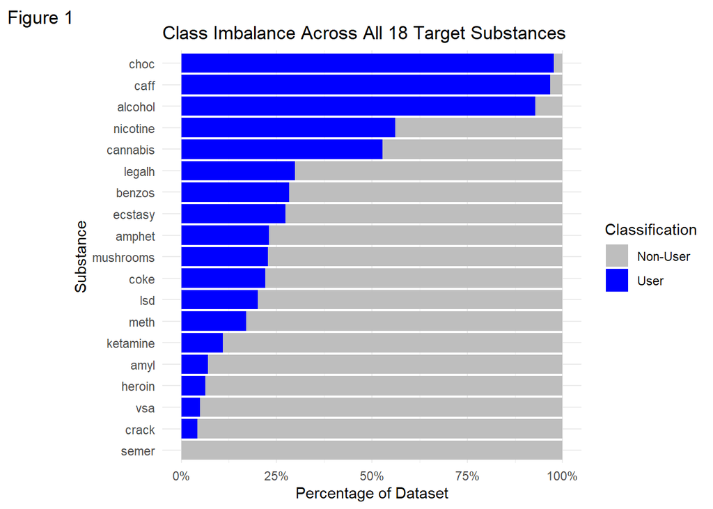

```r
library(readr)

# Reading the file
library(ucimlrepo)
drug_data = fetch_ucirepo(id=373)
data = drug_data$data$original
#head(data)

# Demographic features have already been scaled (Z-score standardization), however drug columns need to be converted
# Rows where individuals claimed "semeron" use need to be removed since it was included as a fake drug

library(dplyr)

# Vector of all the drug column names
drug_cols = c(
  "alcohol", "amphet", "amyl", "benzos", "caff", "cannabis", "choc",
  "coke", "crack", "ecstasy", "heroin", "ketamine", "legalh", "lsd",
  "meth", "mushrooms", "nicotine", "semer", "vsa"
)

target_drugs = c(
  "amphet", "amyl", "benzos", "cannabis",
  "coke", "crack", "ecstasy", "heroin", "ketamine", "legalh", "lsd",
  "meth", "mushrooms", "nicotine", "vsa"
)

# Now we filter out "Semeron" participants by keeping ones that say "never used"
data_cleaned = data %>%
  filter(semer == "CL0")


# Converting drug consumption columns into a binary target (user vs non-user)
# 0(non-user) and 1 (user)
## We will say anyone who has used the particular drug within the last year is a "user"

data_all_binary = data_cleaned %>%
  mutate(across(
    .cols = all_of(drug_cols),
    .fns = ~ ifelse(. %in% c("CL3", "CL4", "CL5", "CL6"), 1, 0)
  ))


# Checking to make sure they are binary
#head(data_all_binary[, c("alcohol", "amphet", "amyl")])


# Now we need to convert the features to a numeric matrix (X)
# Since we only want to train on personality scores, not other drug use, we need to remove other drug columns, too.
X_data = data_all_binary %>%
  select(nscore, escore, oscore, ascore, cscore, impuslive, ss) %>%
  as.matrix()
#dim(X_data)


# Extracting the target variables (drug columns)
y_matrix = data_all_binary %>%
  select(all_of(target_drugs)) %>%
  as.matrix()
# Verifying the shape
#print(paste("Features Matrix (X) shape:", paste(dim(X_data), collapse = "x")))
#print(paste("Multi-Label Target Matrix (y) shape:", paste(dim(y_matrix), collapse = "x")))
y_matrix1 = data_all_binary %>%
  select(all_of(drug_cols)) %>%
  as.matrix()

# Plotting class imbalance
library(ggplot2)
library(tidyr)
library(dplyr)

# Converting matrix to a dataframe
imbalance_plot_data = as.data.frame(y_matrix) %>%
  gather (key = "Drug", value = "Status") %>%
  mutate (Status = ifelse(Status == 1, "User", "Non-User"))

imbalance_plot_data1 = as.data.frame(y_matrix1) %>%
  gather (key = "Drug", value = "Status") %>%
  mutate (Status = ifelse(Status == 1, "User", "Non-User"))

# Creating a bar chart
ggplot(imbalance_plot_data1, aes (x = reorder(Drug, Status == "User", FUN = sum), fill = Status)) +
  geom_bar(position = "fill") +
  scale_y_continuous(labels = scales::percent) +
  scale_fill_manual(values = c("Non-User"= "gray", "User" = "blue"))+
  coord_flip() +
  labs(
    tag = "Figure 1",
    title = "Class Imbalance Across All 18 Target Substances",
    x = "Substance",
    y = "Percentage of Dataset",
    fill = "Classification"
  ) +
  theme_minimal()
```

Based on Figure 1, we noticed two facts about the data: there is a large class imbalance in reported drugs used (very few respondents reporting usage of drugs like crack) and this may cause the model to struggle in predicting use of those, and there are three substances that most if not all respondents reported use of: choc (chocolate), caff (caffeine), and alcohol. This becomes important when we attempt to rectify class imbalances before splitting into train/test groups.

A random split without taking into account this class imbalance can compound the imbalance impact. In order to mitigate this, we introduce the use of a composite score. A sum of substances used is calculated for each of the instances in the dataset then taken into consideration for the train/test split purposes (this results in respondents reporting multiple substances used are balanced between train and test).

We decided to leave out the three most common substances used to make the composite score more reflective of illicit or multi-drug use. This way a person reporting only the use of those three (choc, caff, and alcohol) would now have a composite score of 0 instead of 3 which may be the same as a person who reported use of three illicit drugs (e.g. coke, meth, and crack). The class imbalance after the removal of chocolate, caffeine, and alcohol can be viewed below in Figure 2.

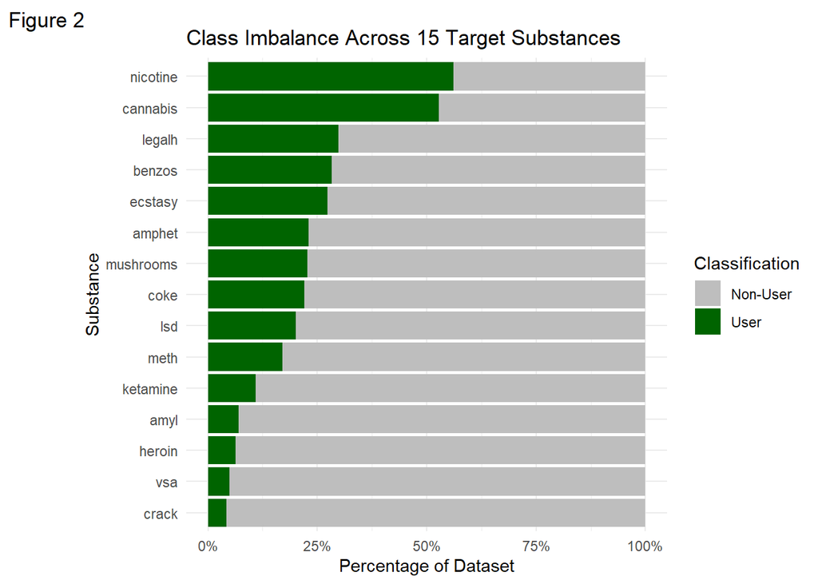

```r
# Since we have imbalance for the majority of the drugs, we need to be careful with our train/test split.
# We will use a composite profile score
library(caret)
set.seed(10)

# By using this method, individuals that use more than one drug will be evenly distributed
composite_score = as.factor(rowSums(y_matrix))

# Conducting the 80/20 split
train_indices = createDataPartition(composite_score, p = 0.80, list = FALSE)

X_train = X_data[train_indices,]
X_test = X_data[-train_indices,]
y_train = y_matrix[train_indices,]
y_test = y_matrix[-train_indices,]

# Testing out the dimensions
#print(paste("X_train:", paste(dim(X_train), collapse = " x ")))
#print(paste("y_train:", paste(dim(y_train), collapse = " x ")))
#print(paste("X_test:", paste(dim(X_test), collapse = " x ")))
#print(paste("y_test:", paste(dim(y_test), collapse = " x ")))

ggplot(imbalance_plot_data, aes (x = reorder(Drug, Status == "User", FUN = sum), fill = Status)) +
  geom_bar(position = "fill") +
  scale_y_continuous(labels = scales::percent) +
  scale_fill_manual(values = c("Non-User"= "gray", "User" = "darkgreen"))+
  coord_flip() +
  labs(
    tag = "Figure 2",
    title = "Class Imbalance Across 15 Target Substances",
    x = "Substance",
    y = "Percentage of Dataset",
    fill = "Classification",
  ) +
  theme_minimal()
```

Figure 3 illustrates the split of users between the train and test groups using a composite score. Based on the approximately equal bars between the train and test categories, it is evident that a fairly even split of users was achieved using this method.

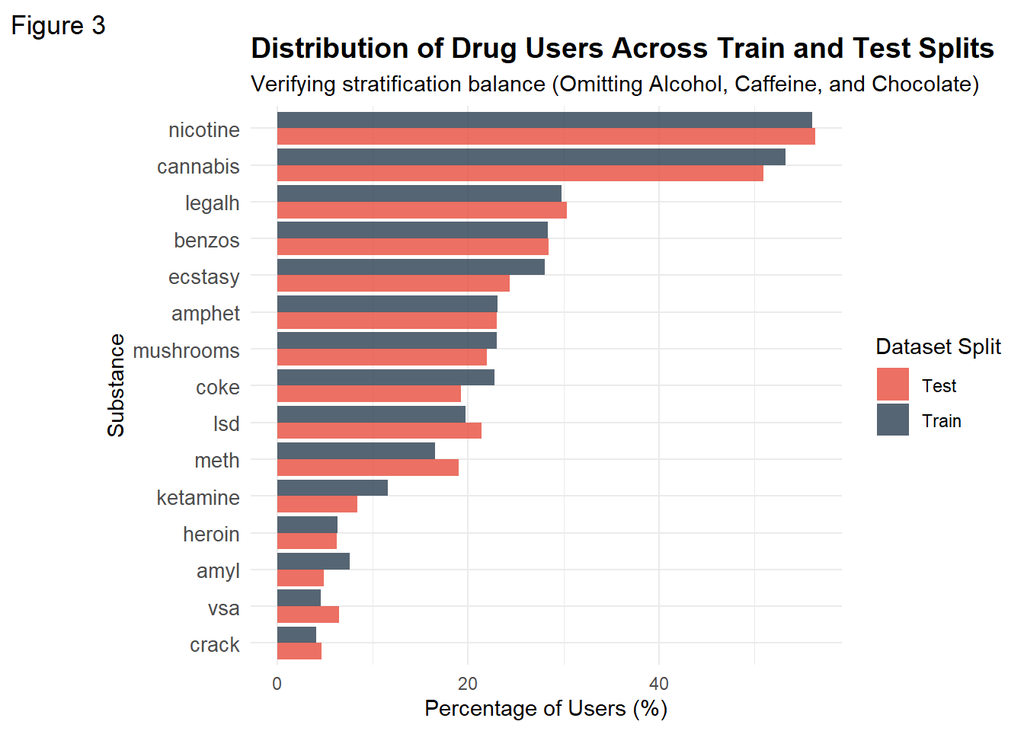

```r
# Calculating the user percentages for the training set
train_dist = as.data.frame(y_train) %>%
  gather(key = "Drug", value = "Status") %>%
  group_by(Drug) %>%
  summarize(User_Percentage = mean(Status == 1) * 100) %>%
  mutate(Split = "Train")

# Calculating the user percentages for the test set
test_dist = as.data.frame(y_test) %>%
  gather(key = "Drug", value = "Status") %>%
  group_by(Drug) %>%
  summarize(User_Percentage = mean(Status == 1) * 100) %>%
  mutate(Split = "Test")

# Combining both distributions into a single dataframe
split_comparison = rbind(train_dist, test_dist)

# Creating the bar chart
ggplot(split_comparison, aes(x = reorder(Drug, User_Percentage), y = User_Percentage, fill = Split)) +
  geom_bar(stat = "identity", position = "dodge", alpha = 0.8) +
  scale_fill_manual(values = c("Train" = "#2c3e50", "Test" = "#e74c3c")) +
  coord_flip() +
  labs(
    tag = "Figure 3",
    title = "Distribution of Drug Users Across Train and Test Splits",
    subtitle = "Verifying stratification balance (Omitting Alcohol, Caffeine, and Chocolate)",
    x = "Substance",
    y = "Percentage of Users (%)",
    fill = "Dataset Split"
  ) +
  theme_minimal() +
  theme(
    plot.title = element_text(face = "bold", size = 14),
    axis.text.y = element_text(size = 10)
  )
```

We wanted to examine the typical personality types that were associated with some of these drugs to identify if there were strong overlaps that might impact the predictive ability of our models. Figures 4 and 5 illustrate a “psychological footprint” of a user of two of our target substances. The blue ring identifies a typical “non-user” and the red ring identifies a typical user. The gaps between the red ring and the blue ring at the individual personality points indicate an larger or smaller propensity for that particular trait.

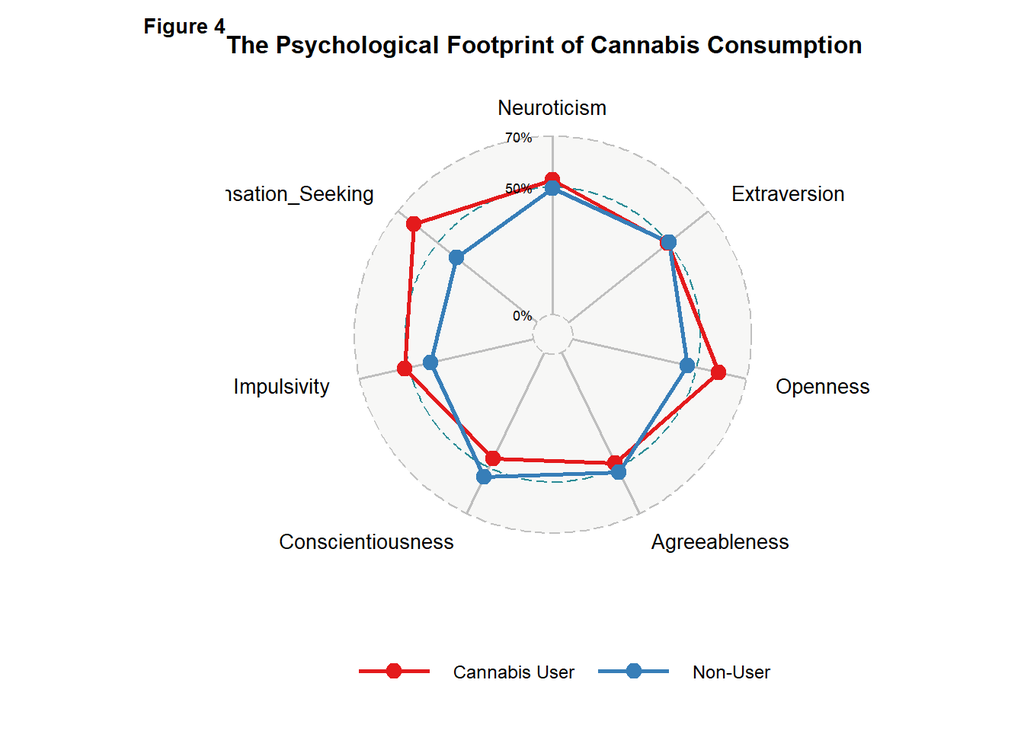

```r
library(dplyr)
library(tidyr)
# Installing remotes
if (!requireNamespace("remotes", quietly = TRUE)) {
  install.packages("remotes")
}

# Downloading and installing ggradar from GitHub
library(ggradar)

min_max_scale = function(x) {
  (x - min(x, na.rm = TRUE)) / (max(x, na.rm = TRUE) - min(x, na.rm = TRUE))
}

# Scaling the raw respondent traits globally
data_scaled_global = data_all_binary %>%
  mutate(across(c(nscore, escore, oscore, ascore, cscore, impuslive, ss), min_max_scale))

# Preparing aggregate averages for cannabis
footprint_cannabis = data_scaled_global %>%
  group_by(cannabis) %>%
  summarise(across(c(nscore, escore, oscore, ascore, cscore, impuslive, ss), mean)) %>%
  rename(group = cannabis) %>%
  mutate(group = ifelse(group == 1, "Cannabis User", "Non-User"))

colnames(footprint_cannabis) <- c("group", "Neuroticism", "Extraversion", "Openness", "Agreeableness", "Conscientiousness", "Impulsivity", "Sensation_Seeking")

# Generating the Radar Chart explicitly using the new meth object
ggradar(
  plot.data = footprint_cannabis,
  grid.min = 0, grid.mid = 0.5, grid.max = 0.7,
  values.radar = c("0%", "50%", "70%"),
  group.point.size = 3, group.line.width = 1, legend.position = "bottom",

  axis.label.size = 3.5,     # Shrinks trait names (Neuroticism, Impulsivity, etc.)
  grid.label.size = 3,       # Shrinks the percentage labels (0%, 50%, 100%)
  legend.text.size = 9       # Shrinks the legend text at the bottom
) +
  labs(
    title = "The Psychological Footprint of Cannabis Consumption",
    tag = "Figure 4"
  ) +
  theme(
    plot.tag = element_text(size = 10, face = "bold"),           # Neat, small"Figure 4"
    plot.title = element_text(size = 12, face = "bold"),         # Small, crisp title
    legend.title = element_text(size = 9)                        # Small legend title
  )
```

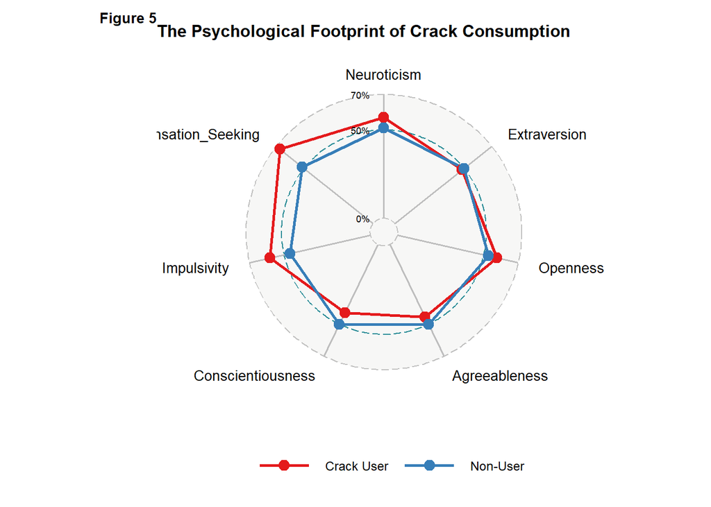

```r
# Scaling the raw respondent traits globally
data_scaled_global = data_all_binary %>%
  mutate(across(c(nscore, escore, oscore, ascore, cscore, impuslive, ss), min_max_scale))

# Preparing aggregate averages for crack
footprint_crack = data_scaled_global %>%
  group_by(crack) %>%
  summarise(across(c(nscore, escore, oscore, ascore, cscore, impuslive, ss), mean)) %>%
  rename(group = crack) %>%
  mutate(group = ifelse(group == 1, "Crack User", "Non-User"))

colnames(footprint_crack) = c("group", "Neuroticism", "Extraversion", "Openness", "Agreeableness", "Conscientiousness", "Impulsivity", "Sensation_Seeking")

# Generating the Radar Chart explicitly using the new crack object
ggradar(
  plot.data = footprint_crack,
  grid.min = 0, grid.mid = 0.5, grid.max = 0.7,
  values.radar = c("0%", "50%", "70%"),
  group.point.size = 3, group.line.width = 1, legend.position = "bottom",

  axis.label.size = 3.5,
  grid.label.size = 3,
  legend.text.size = 9
) +
  labs(
    title = "The Psychological Footprint of Crack Consumption",
    tag = "Figure 5"
  ) +
  theme(
    plot.tag = element_text(size = 10, face = "bold"),           # Neat, small "Figure 5"
    plot.title = element_text(size = 12, face = "bold"),         # Small, crisp title
    legend.title = element_text(size = 9)                        # Small legend title
  )
```

Examining the resulting polygons shows us that a user of cannabis is more likely to exhibit traits of sensation seeking and openness more than that reported in non-users. Additionally, the polygon for a crack user shows a larger disparity between non-users and users for the sensation seeking and impulsivity categories with a lower-than-non-user response for conscientiousness and agreeableness. Generally though, the red polygons trend in similar directions for users vs non-users. This raises the question of how correlated usage of drugs is in this dataset.

We use a correlation matrix (Figure 6) to illustrate this tendency towards drugs used together. Figure 6 confirms the strong ties between use of multiple substances. As the lines increase in darkness, the strength of the usage correlation increases. These correlations as well as the overlapping psychological footprint maps indicate that many respondents likely reported the use of multiple drugs. This information becomes important later when deciding on an activation function for our output level. Do we want to predict across all drugs where the probabilities add to 1? Our data indicate that use of these drugs is not mutually exclusive, thus we want to predict from 0 to 1 for each individual drug as a respondent can have a high probability of using two ore more drugs.

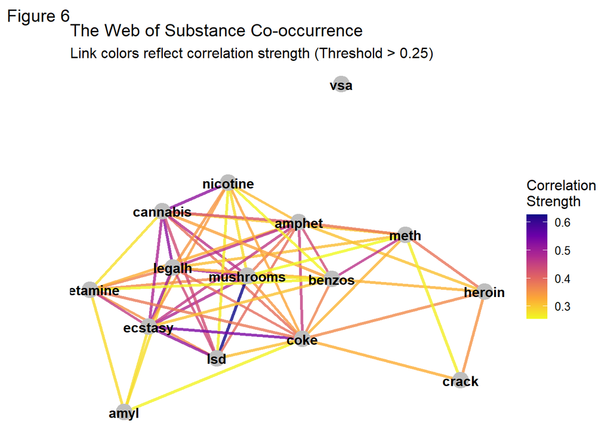

```r
library(reshape2)
library(igraph)
library(ggnetwork)
library(ggplot2)

# Calculating correlation matrix between all 15 remaining drugs
drug_corr = cor(y_matrix)
diag(drug_corr) = 0

# Filtering out weak connections
drug_corr[abs(drug_corr) < 0.25] = 0

# Building the network object
network_structure = graph_from_adjacency_matrix(drug_corr, weighted = TRUE, mode = "undirected")

# Generating spaced coordinates using a scaling trick
set.seed(123)

# We pass an inverse weight array (1 - correlation) or a fixed small weight
# to force the Fruchterman-Reingold layout to push nodes further apart
spaced_layout = layout_with_fr(
  network_structure,
  niter = 1500,
  weights = rep(0.1, ecount(network_structure)) # Lower weight = weaker springs = more spread out!
)

# Converting to ggnetwork using our custom spaced coordinates
network_data = ggnetwork(network_structure, layout = spaced_layout)

# Plotting the spacious layout
ggplot(network_data, aes(x = x, y = y, xend = xend, yend = yend)) +

  # Mapping link color to the correlation weight and make lines thicker
  geom_edges(aes(color = weight), size = 1.2, alpha = 0.8) +

  # Gradient palette for the links (e.g., yellow to red for low to high correlation)
  scale_color_viridis_c(option = "plasma", name = "Correlation\nStrength", direction = -1) +

  # Uniform node coloring (a clean slate grey or dark blue so the links pop)
  geom_nodes(color = "gray", size = 6) +

  # Labels positioned neatly over the nodes
  geom_nodetext(aes(label = name), fontface = "bold", color = "black", size = 4) +

  theme_blank() +
  labs(
    tag = "Figure 6",
    title = "The Web of Substance Co-occurrence",
    subtitle = "Link colors reflect correlation strength (Threshold > 0.25)"
  ) +
  theme(
    legend.position = "right"
  )
```

## Modeling

### The ANN

A two-layer MLP was constructed as described above in the methods section, utilizing ReLU activation on input and hidden layers, and a sigmoid activation function on output. The below plot of binary accuracy and loss vs epoch shows the progress of the model.

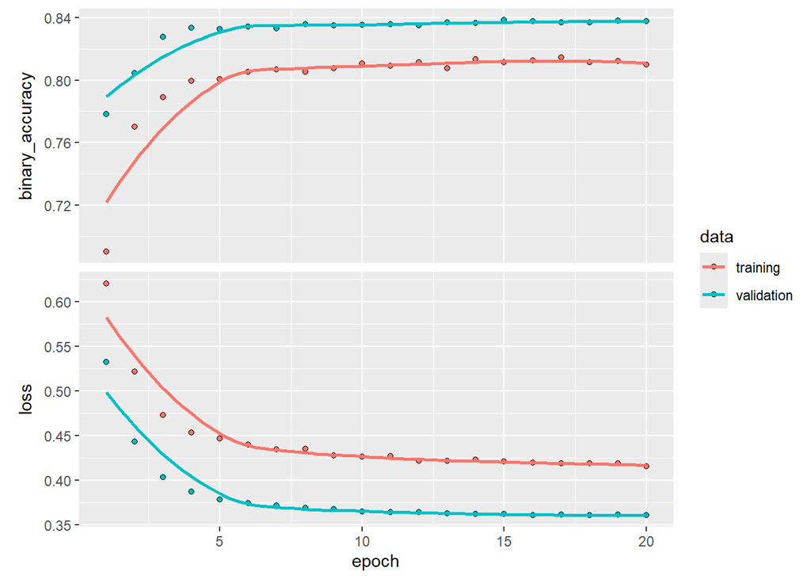

```r
######## READY FOR MLP USE WITH THIS TRAIN/TEST DATA########

library(keras3)
library(tensorflow)
# install.packages("keras3")

set.seed(10)
# Input layer
inputs = layer_input(shape = c(7))

outputs = inputs %>%
  layer_dense(units = 64, activation = 'relu') %>%
  layer_dropout(rate = 0.3) %>%
  layer_dense(units = 32, activation = 'relu') %>%
  layer_dropout(rate = 0.2) %>%
  layer_dense(units = 15, activation = 'sigmoid')

mlp_model = keras_model(input = inputs, output = outputs)

# Compiling the model
mlp_model %>% compile(
  optimizer = 'adam',
  loss = 'binary_crossentropy',
  metrics = c('binary_accuracy')
)
history = mlp_model %>% fit(
  x = X_train,
  y = y_train,
  epochs = 20,
  batch_size = 32,
  validation_split = 0.2,
  verbose = 0
)
plot(history)
```

```r
# Evaluating the effectiveness of this model using F1 score
library(yardstick)
# Converting props to binary
pred_probs = predict(mlp_model, X_test, verbose = 0)
pred_binary = ifelse(pred_probs > 0.5, 1, 0)
results = data.frame(truth = as.matrix(y_test, estimate = pred_binary))

# Calculating for each drug individually with dynamic thresholds
eval_results_mlp = data.frame()

for(i in 1:ncol(y_test)){
  drug_name = target_drugs[i]

  # 1. Calculate the actual base rate (proportion of 1s in the ground truth)
  actual_use_rate = mean(y_test[, i] == 1)

  # 2. Set the threshold so that ONLY the top percentage (matching the base rate) are predicted as 1s
  # If 10% of people use a drug, the threshold is the 90th percentile (1 - 0.10)
  current_threshold = actual_use_rate

  # Converting to binary using this column's class-balanced threshold
  binary_preds = ifelse(pred_probs[, i] >= current_threshold, 1, 0)

  truth_vec    = factor(y_test[, i], levels = c(0, 1))
  estimate_vec = factor(binary_preds, levels = c(0, 1))

  # Calculating metrics
  f1   = f_meas_vec(truth_vec, estimate_vec, event_level = "second")
  prec = precision_vec(truth_vec, estimate_vec, event_level = "second")
  rec  = recall_vec(truth_vec, estimate_vec, event_level = "second")

  eval_results_mlp = rbind(eval_results_mlp, data.frame(
    Drug = drug_name,
    Threshold = as.numeric(current_threshold), # tracked to see what was used
    F1 = ifelse(is.na(f1), 0, f1),
    Precision = ifelse(is.na(prec), 0, prec),
    Recall = ifelse(is.na(rec), 0, rec)
  ))
}
print(eval_results_mlp)
```

```
        Drug  Threshold        F1  Precision    Recall
1     amphet 0.23035230 0.5019305 0.37356322 0.7647059
2       amyl 0.04878049 0.1227437 0.06563707 0.9444444
3     benzos 0.28455285 0.5804196 0.45856354 0.7904762
4   cannabis 0.50948509 0.7715736 0.73786408 0.8085106
5       coke 0.19241192 0.4522968 0.30188679 0.9014085
6      crack 0.04607046 0.1325301 0.07382550 0.6470588
7    ecstasy 0.24390244 0.5387205 0.38647343 0.8888889
8     heroin 0.06233062 0.2043011 0.11656442 0.8260870
9   ketamine 0.08401084 0.2255639 0.12765957 0.9677419
10    legalh 0.30352304 0.6736842 0.55491329 0.8571429
11       lsd 0.21409214 0.5541126 0.42105263 0.8101266
12      meth 0.18970190 0.4636364 0.34000000 0.7285714
13 mushrooms 0.21951220 0.5055762 0.36170213 0.8395062
14  nicotine 0.56368564 0.6956522 0.74316940 0.6538462
15       vsa 0.06504065 0.2400000 0.14285714 0.7500000
```

The above table shows each drug, the threshold used for that drug, and the corresponding F1 score (grading how well the model predicted drug use), precision, and recall. A blanket predicted probability threshold of 0.5 (where probabilities over 0.5 were assigned class 1-user) was inappropriate for every drug. Some drugs probabilities capped out around 7%, thus all predicted instances would be 0 with the 50% threshold. Instead, a dynamic threshold was implemented where the base rate of susbstance use was used was used as the threshold for which the model classified a ‘user’. For example, if the base rate of a substance use is 10%, and a prediction was given at 0.11, this was categorized as a 1 (user). As expected, drugs with the lowest F1 scores also have some of the lowest precision, accuracy, and threshold, likely because they are more rare substances in use and therefore have the lowest occurrence and represent the classes most imbalanced (amyl, crack, heroin, and ketamine).

Additionally, we discovered that using the metric “accuracy” was misrepresenting of the performance of the model. The metric “accuracy” only grades the model positively if it correctly predicted ALL of the 15 target substances. If the model correctly predicted 14 out of the 15 substances, that was considered a model failure. As we are looking at prediction of each drug independently, we updated the metric of the model to “binary accuracy” which represents how many of the 15 drugs it predicts correctly for each instance in the data set. This model is performing at approaching 85% accuracy overall.

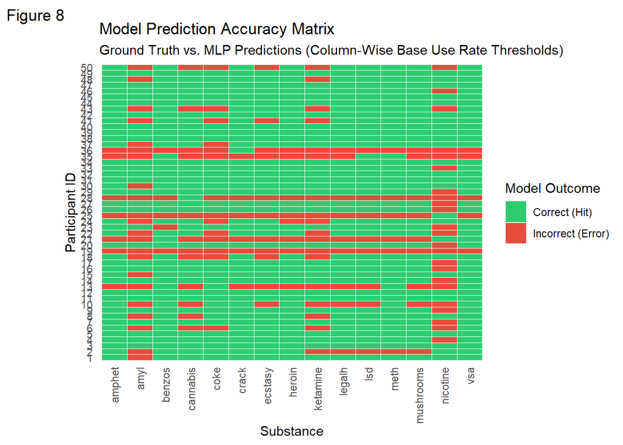

```r
# Heat map for the first 50 participant's likelihood profile
# Generate predicted probabilities

all_probs = predict(mlp_model, X_test, verbose = 0)
y_test_matrix = as.matrix(y_test[, target_drugs])

all_preds = all_probs # copy structure

for(i in 1:ncol(all_probs)) {
  drug_name = target_drugs[i]
  # 1. Find the actual proportion of users for this drug in the test set
  actual_use_rate = mean(y_test_matrix[, drug_name])

  # 2. Find the corresponding percentile threshold (e.g., if use rate is 10%, threshold is the 90th percentile)
  class_threshold = actual_use_rate

  # 3. Classify based on this realistic, drug-specific threshold
  all_preds[, i] = ifelse(all_probs[, i] >= class_threshold, 1, 0)
}

# Ensure colnames are preserved from the target drugs
colnames(all_preds) = target_drugs

# Ensure y_test matches all_preds in dimension and order
# Convert y_test to a clean matrix and align columns with your target drugs


# Double checking rows
if (nrow(y_test_matrix) != nrow(all_preds)) {
  y_test_matrix = tail(y_test_matrix, nrow(all_preds))
}

# Calculating correctness element-by-element
is_correct = (all_preds == y_test_matrix)

# Converting to dataframe and adding Participant IDs
df_correct = as.data.frame(is_correct)
df_correct$Participant = 1:nrow(df_correct)

# Reshaping to long format for ggplot
df_correct_long = df_correct %>%
  pivot_longer(cols = -Participant, names_to = "Drug", values_to = "Accuracy") %>%
  mutate(Classification = ifelse(Accuracy == 1, "Correct (Hit)", "Incorrect (Error)"))

# Filtering for the first 50 participants
df_correct_subset = df_correct_long %>% filter(Participant <= 50)

# Creating the Evaluation Heatmap
ggplot(data = df_correct_subset, aes(x = Drug, y = factor(Participant), fill = Classification)) +
  geom_tile(color = "white", size = 0.1) +
  scale_fill_manual(values = c("Correct (Hit)" = "#2ecc71", "Incorrect (Error)" = "#e74c3c")) +
  theme_minimal() +
  theme(
    axis.text.x = element_text(angle = 90, hjust = 1, vjust = 0.5),
    panel.grid = element_blank()
  ) +
  labs(
    tag = "Figure 8",
    title = "Model Prediction Accuracy Matrix",
    subtitle = "Ground Truth vs. MLP Predictions (Column-Wise Base Use Rate Thresholds)",
    x = "Substance",
    y = "Participant ID",
    fill = "Model Outcome"
  )
```

To explore how this model could be used in a clinical setting to identify “at risk” individuals, we constructed a synthetic profile of an imaginary respondent to the survey and examined how the model is able to predict the probability of drug usage across our 15 target substances.

```r
# Creating a fake respondent
new_respondent = data.frame(
  nscore    =  0.13606,  # Neuroticism
  escore    = -0.43999,  # Extraversion
  oscore    =  0.29338,  # Openness
  ascore    = -0.15487,  # Agreeableness
  cscore    = -0.52745,  # Conscientiousness
  impuslive =  0.19268,  # Impulsivity
  ss        =  0.40148   # Sensation Seeking
)

# Converting to a 1-row matrix so Keras can read it
new_respondent_matrix = as.matrix(new_respondent)

new_response_pred_probs = predict(mlp_model, new_respondent_matrix, verbose = 0)

# Creating an empty data frame to hold the predictions
single_predictions = data.frame(
  Drug = target_drugs,
  Probability = round(as.numeric(new_response_pred_probs[1, ]), 4)
)

single_predictions_sorted = single_predictions %>%
  arrange(desc(Probability))

# Viewing the ordered risk profile
print(single_predictions_sorted)
```

```
        Drug Probability
1   cannabis      0.7459
2   nicotine      0.6786
3     legalh      0.4762
4    ecstasy      0.4373
5  mushrooms      0.4351
6     amphet      0.4071
7     benzos      0.3989
8        lsd      0.3786
9       coke      0.3399
10      meth      0.3355
11  ketamine      0.2573
12      amyl      0.2195
13    heroin      0.1903
14     crack      0.1489
15       vsa      0.1458
```

### The RNN

A two-layer RNN was then constructed as described above in the methods section, utilizing a, LSTM layer of 64 neurons followed by an output layer consisting of 15 neurons and a sigmoid activation function. The plot below of binary accuracy and loss vs epoch shows the progress of the RNN model.

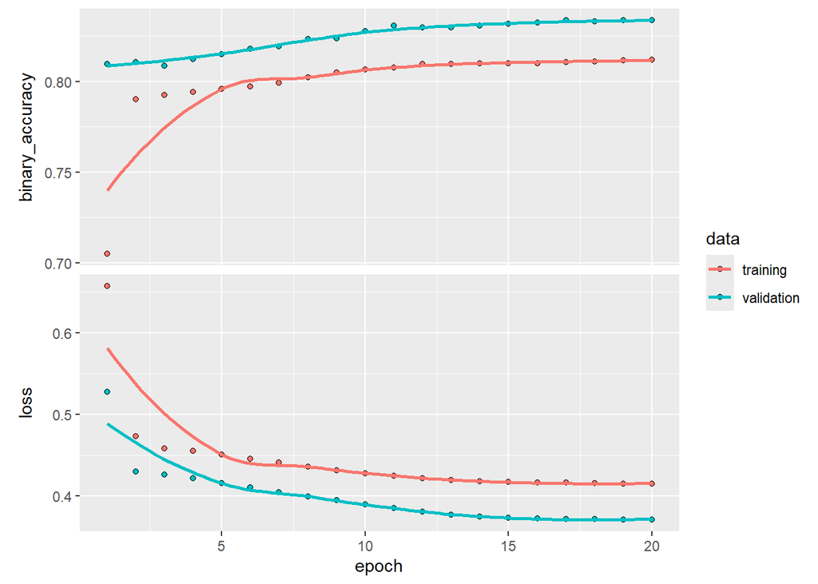

```r
# Reshaping the data for RNN
X_train_rnn = array_reshape(as.matrix(X_train), c(nrow(X_train), 7, 1))
X_test_rnn = array_reshape(as.matrix(X_test), c(nrow(X_test), 7, 1))

set.seed(10)

# RNN model
inputs = layer_input(shape = c(7, 1))
outputs = inputs %>%
  layer_lstm(units = 64) %>%
  layer_dense(units = 15, activation = 'sigmoid')

rnn_model = keras_model(inputs = inputs, outputs = outputs)

rnn_model %>% compile(
  optimizer = 'adam',
  loss = 'binary_crossentropy',
  metrics = c('binary_accuracy') # Tracks binary accuracy over epochs
)

# Fitting the model
rnn_history = rnn_model %>% fit(
  x = X_train_rnn,
  y = y_train,
  epochs = 20,
  batch_size = 32,
  validation_split = 0.2,
  verbose = 0
)

#
plot(rnn_history)
```

```r
# Evaluating the effectiveness of this model using F1 score

library(yardstick)
pred_probs_rnn = predict(rnn_model, X_test_rnn, verbose = 0)
# Fixed typo: changed pred_probs to pred_probs_rnn
pred_binary_rnn = ifelse(pred_probs_rnn > 0.5, 1, 0)
results = data.frame(truth = as.matrix(y_test, estimate = pred_binary_rnn))

# Calculating for each drug individually with dynamic thresholds
eval_results_rnn = data.frame()

for(i in 1:ncol(y_test)){
  drug_name = target_drugs[i]

  # 1. Calculate the actual base rate (proportion of 1s in the ground truth)
  actual_use_rate = mean(y_test[, i] == 1)

  # 2. Set the threshold so that ONLY the top percentage (matching the base rate) are predicted as 1s
  current_threshold = actual_use_rate

  # Converting to binary using this column's class-balanced threshold
  binary_preds = ifelse(pred_probs_rnn[, i] >= current_threshold, 1, 0)

  truth_vec    = factor(y_test[, i], levels = c(0, 1))
  estimate_vec = factor(binary_preds, levels = c(0, 1))

  # Calculating metrics
  f1   = f_meas_vec(truth_vec, estimate_vec, event_level = "second")
  prec = precision_vec(truth_vec, estimate_vec, event_level = "second")
  rec  = recall_vec(truth_vec, estimate_vec, event_level = "second")

  eval_results_rnn = rbind(eval_results_rnn, data.frame(
    Drug = drug_name,
    Threshold = as.numeric(current_threshold), # tracked to see what was used
    F1 = ifelse(is.na(f1), 0, f1),
    Precision = ifelse(is.na(prec), 0, prec),
    Recall = ifelse(is.na(rec), 0, rec)
  ))
}

print(eval_results_rnn)
```

```
        Drug  Threshold        F1  Precision    Recall
1     amphet 0.23035230 0.5080645 0.38650307 0.7411765
2       amyl 0.04878049 0.1180556 0.06296296 0.9444444
3     benzos 0.28455285 0.5294118 0.43113772 0.6857143
4   cannabis 0.50948509 0.7379135 0.70731707 0.7712766
5       coke 0.19241192 0.4701754 0.31308411 0.9436620
6      crack 0.04607046 0.1503759 0.08620690 0.5882353
7    ecstasy 0.24390244 0.5166052 0.38674033 0.7777778
8     heroin 0.06233062 0.2057143 0.11842105 0.7826087
9   ketamine 0.08401084 0.2151394 0.12272727 0.8709677
10    legalh 0.30352304 0.6353791 0.53333333 0.7857143
11       lsd 0.21409214 0.5213270 0.41666667 0.6962025
12      meth 0.18970190 0.3703704 0.29411765 0.5000000
13 mushrooms 0.21951220 0.4916667 0.37106918 0.7283951
14  nicotine 0.56368564 0.6835443 0.72192513 0.6490385
15       vsa 0.06504065 0.2148760 0.13402062 0.5416667
```

The table above shows the substances as well as their corresponding threshold, F1 score, precision, and recall. The same dynamic threshold that was implemented in our MLP model was used in this RNN model, which also shows the aligned F1, precision, and recall scores. For highly rare substances like amyl, our test set contained very few positive instances. Under the class-balanced threshold we are using for the MLP and RNN, incorrectly categorizing even a single actual user in our predictions can drop our True Positives to zero, resulting in an F1 score of 0. This highlights how extremely imbalanced classes remain a significant challenge, even for complex architectures.

### Comparing Effectiveness of MLP and RNN Models

To directly compare the effectiveness of the MLP and RNN models, the recall values for each model were plotted side-by-side across each of the 15 non-mutually exclusive substances in Figure 9. Since both models used an adaptive threshold to help combat class imbalance observed in the dataset, we are able to compare the scores to evaluate how effectively each model could predict drug usage based on personality type information.

[figure not shown]

```r
library(ggplot2)
library(dplyr)

plot_data = rbind(
  mutate(eval_results_mlp, Model = "MLP"),
  mutate(eval_results_rnn, Model = "RNN")
)

ggplot(plot_data, aes(x = Drug, y = Recall, fill = Model)) +
  geom_bar(stat = "identity", position = "dodge") +
  theme_minimal() +
  labs(tag= "Figure 9", title = "Recall (sensitivity) Comparison: MLP vs RNN", y = "F1 Score") +
  theme(axis.text.x = element_text(angle = 90, hjust = 1))
```

Based on Figure 9, there was one instance where the RNN model outperformed the MLP model, and this was for the cocaine category. In this case, the sequential memory of the RNN allowed the layers to learn complicated interactions between the personality trait data that may have been overlooked using the MLP model. Overall, while the MLP remains the most computationally efficient and accurate of the two models evaluated, the RNN’s step-by-step memory framework provided an advantage when isolating unique behavioral relationships within the data.

### Conclusion

This study successfully evaluated the effectiveness of MLP and RNN models in predicting substance usage risks using the Revised NEO Five-Factor Inventory, Barratt Impulsiveness, and the Impulsive Sensation Seeking scales. One of the main features of this study is the use of multi-label classification to treat substances as non-mutually exclusive categories in order to accurately reflect the real-world complexity of multi-substance use behavior.

The results of this study demonstrate that personality traits can be good indicators for substance usage risk when using ANN model frameworks, with an overall binary accuracy rate of approximately 82% for each model developed. The use of an adaptive threshold resulted in the best model accuracy and a subsequently balanced F1, precision, and recall scores however it is sensitive to extreme class imbalances for rare substances. Overall, we found that the risk of casting a broader net resulted in an inflated number of false positives. In the context of identifying at-risk individuals, we found the risk of a false positive to be less than the risk of a false negative.

Ultimately, this study revealed that our MLP model is more efficient and generally more accurate for multi-label classification when compared to our RNN model. By evaluating all of the features simultaneously, the MLP was easily able to map correlations across the data. However, the RNN’s success in the cocaine category does validate the use of a “pseudo-sequential” feature extraction method, showing that an LSTM’s step-by-step memory framework can provide an advantage when looking at rare and complex relationships within personality data. Additionally, without setting a seed, the model would often show that the RNN could outperform the MLP for other drugs, suggesting that both models perform equally well and given the run through the dataset, the MLP or the RNN would produce concordant results.

The goal of this study was to determine drug use in a way that does not consider substances to be mutually exclusive. During the process of this study we found that individuals with certain personality traits may be more likely to gravitate towards a grouping of drugs, such as hallucinogens, or depressants. To further expand on this study, it may be beneficial to explore which substances are consistently indicated at the same rate and essentially group them by class to determine if the model performance can be improved using grouped substance classes instead of individual, mutually-exclusive drug targets. Additionally, the significant class imbalance observed within the dataset could be further mitigated using a synthetic data generation method, such as Synthetic Minority Over-Sampling (SMOTE).This could improve the overall performance of the models when handling the under-represented substances. Additionally, the model struggled with the nicotine category as evidenced in the hit or miss heatmap (Figure 8), this was also the fourth most used substance in the dataset. Omission of nicotine could improve model performance with limited risk as it is not an illicit substance.

## References

Costa, Paul T, and Robert R McCrae. 1992. *Revised NEO Personality Inventory (NEO-PI-r) and NEO Five-Factor Inventory (NEO-FFI) Professional Manual*. Psychological Assessment Resources.

Ekundayo, Olufisayo S., and Absalom E. Ezugwu. 2025. “Deep Learning: Historical Overview from Inception to Actualization, Models, Applications and Future Trends.” *Applied Soft Computing* 181: 113378. https://doi.org/10.1016/j.asoc.2025.113378.

El-Mandouh, Mahmoud A., Hassan Youssef, M. S. Elborlsy, and Mostafa A. Ebied. 2026. “Comparing Machine Learning and Deep Learning Approaches to Predicting the Seismic Response of Slab-Column Connections.” *Scientific Reports* 16 (1): 14718. https://doi.org/10.1038/s41598-026-50962-9.

Fehrman, Elaine, Awaz Kakamam Muhammad, Evgeny M. Mirkes, Vincent Egan, and Alexander N. Gorban. 2017. “The Five Factor Model of Personality and Evaluation of Drug Consumption Risk.” In *Data Science: Innovative Developments in Data Analysis and Clustering*. Springer International Publishing. https://doi.org/10.1007/978-3-319-55723-6_18.

Larochelle, Hugo, Yoshua Bengio, J ’er ^ome Louradour, and Pascal Lamblin. 2009. “Exploring Strategies for Training Deep Neural Networks.” *Journal of Machine Learning Research* 10: 1–40. https://doi.org/10.1145/1577069.1577070.

Montesinos Lóperz, Osval Antonio, Abelardo Montesinos López, and Jose Crossa. 2022. “Fundamentals of Artificial Neural Networks and Deep Learning.” In *Multivariate Statistical Machine Learning Methods for Genomic Prediction*. Springer, Cham. https://doi.org/10.1007/978-3-030-89010-0_10.

Przybyła-Kasperek, Małgorzata, and Kwabena Frimpong Marfo. 2024. “A Multi-Layer Perceptron Neural Network for Varied Conditional Attributes in Tabular Dispersed Data.” *PLoS ONE* 19 (12): e0311041. https://doi.org/10.1371/journal.pone.0311041.

Rumelhart, David E., Geoffrey E. Hinton, and Ronald J. Williams. 1986. “Learning Representations by Back-Propagating Errors.” *Nature* 323 (6088): 533–36. https://doi.org/10.1038/323533a0.